# BTS 510 Lab 7

```r
set.seed(12345)
library(tidyverse)
library(Stat2Data)
theme_set(theme_classic(base_size = 16))
```

## 1 Learning objectives

- **Add predictors** to a linear regression model
- Interpret **partial regression coefficients**
- **Re-code predictors** to answer your research questions
- **Compare** different models using $R^2_{change}$

## 2 Data

- `ICU` data from the **Stat2Data** package
  - `ID`: Patient ID code
  - `Survive`: 1 = patient survived to discharge or 0 = patient died
  - `Age`: Age (in years)
  - `AgeGroup`: 1 = young (under 50), 2 = middle (50-69), 3 = old (70+)
  - `Sex`: 1 = female or 0 = male
  - `Infection`: 1 = infection suspected or 0 = no infection
  - `SysBP`: Systolic blood pressure (in mm of Hg)
  - `Pulse`: Heart rate (beats per minute)
  - `Emergency`: 1 = emergency admission or 0 = elective admission

## 3 Research question

**How do infection status (`Infection`) and admission type (`Emergency`) predict blood pressure?**

## 4 Tasks

```r
library(Stat2Data)
data(ICU)
```

1. Conduct **three linear regression models** to address the above research questions.
- Model 1: Infection status predicts blood pressure
- Model 2: Admission type predicts blood pressure
- Model 3: Infection status *and* admission type predict blood pressure

```r
m1 <- lm(data = ICU, SysBP ~ Infection)
m2 <- lm(data = ICU, SysBP ~ Emergency)
m3 <- lm(data = ICU, SysBP ~ Infection + Emergency)
```

```r
summary(m1)
```

```
Call:
lm(formula = SysBP ~ Infection, data = ICU)

Residuals:
    Min      1Q  Median      3Q     Max
-87.452 -18.672  -2.062  18.548 117.328

Coefficients:
            Estimate Std. Error t value Pr(>|t|)
(Intercept)  138.672      2.986  46.440  < 2e-16 ***
Infection    -15.220      4.608  -3.303  0.00113 **
---
Signif. codes:  0 '***' 0.001 '**' 0.01 '*' 0.05 '.' 0.1 ' ' 1

Residual standard error: 32.16 on 198 degrees of freedom
Multiple R-squared:  0.05223,   Adjusted R-squared:  0.04744
F-statistic: 10.91 on 1 and 198 DF,  p-value: 0.001134
```

```r
summary(m2)
```

```
Call:
lm(formula = SysBP ~ Emergency, data = ICU)

Residuals:
    Min      1Q  Median      3Q     Max
-92.646 -18.646  -0.502  17.426 127.354

Coefficients:
            Estimate Std. Error t value Pr(>|t|)
(Intercept)  142.358      4.460  31.918  < 2e-16 ***
Emergency    -13.712      5.202  -2.636  0.00906 **
---
Signif. codes:  0 '***' 0.001 '**' 0.01 '*' 0.05 '.' 0.1 ' ' 1

Residual standard error: 32.47 on 198 degrees of freedom
Multiple R-squared:  0.0339,    Adjusted R-squared:  0.02902
F-statistic: 6.947 on 1 and 198 DF,  p-value: 0.009061
```

```r
summary(m3)
```

```
Call:
lm(formula = SysBP ~ Infection + Emergency, data = ICU)

Residuals:
    Min      1Q  Median      3Q     Max
-85.455 -18.694  -1.231  18.657 120.992

Coefficients:
            Estimate Std. Error t value Pr(>|t|)
(Intercept)  146.194      4.569  31.995  < 2e-16 ***
Infection    -13.553      4.630  -2.927  0.00382 **
Emergency    -11.186      5.178  -2.160  0.03196 *
---
Signif. codes:  0 '***' 0.001 '**' 0.01 '*' 0.05 '.' 0.1 ' ' 1

Residual standard error: 31.87 on 197 degrees of freedom
Multiple R-squared:  0.07416,   Adjusted R-squared:  0.06476
F-statistic:  7.89 on 2 and 197 DF,  p-value: 0.0005054
```

```r
library(modelsummary)
modelsummary(list(m1, m2, m3))
```

|  | (1) | (2) | (3) |
| --- | --- | --- | --- |
| (Intercept) | 138.672 | 142.358 | 146.194 |
|  | (2.986) | (4.460) | (4.569) |
| Infection | -15.220 |  | -13.553 |
|  | (4.608) |  | (4.630) |
| Emergency |  | -13.712 | -11.186 |
|  |  | (5.202) | (5.178) |
| Num.Obs. | 200 | 200 | 200 |
| R2 | 0.052 | 0.034 | 0.074 |
| R2 Adj. | 0.047 | 0.029 | 0.065 |
| AIC | 1959.9 | 1963.7 | 1957.2 |
| BIC | 1969.8 | 1973.6 | 1970.4 |
| Log.Lik. | -976.933 | -978.849 | -974.592 |
| F | 10.911 | 6.947 | 7.890 |
| RMSE | 32.00 | 32.31 | 31.63 |

```r
cor(ICU[, c(6, 7, 9)])
```

```
           Infection      SysBP  Emergency
Infection  1.0000000 -0.2285386  0.1666485
SysBP     -0.2285386  1.0000000 -0.1841112
Emergency  0.1666485 -0.1841112  1.0000000
```

2. **Which is the best model?**
- Use the $F$-test for $R^2_{change}$ and the AIC values to help you decide. Report the tests and values that you used to decide this.

```r
anova(m3, m1)
```

```
Analysis of Variance Table

Model 1: SysBP ~ Infection + Emergency
Model 2: SysBP ~ Infection
  Res.Df    RSS Df Sum of Sq      F  Pr(>F)
1    197 200057
2    198 204796 -1   -4739.2 4.6668 0.03196 *
---
Signif. codes:  0 '***' 0.001 '**' 0.01 '*' 0.05 '.' 0.1 ' ' 1
```

```r
anova(m3, m2)
```

```
Analysis of Variance Table

Model 1: SysBP ~ Infection + Emergency
Model 2: SysBP ~ Emergency
  Res.Df    RSS Df Sum of Sq      F   Pr(>F)
1    197 200057
2    198 208758 -1   -8700.7 8.5677 0.003824 **
---
Signif. codes:  0 '***' 0.001 '**' 0.01 '*' 0.05 '.' 0.1 ' ' 1
```

```r
AIC(m1)
```

```
[1] 1959.866
```

```r
AIC(m2)
```

```
[1] 1963.698
```

```r
AIC(m3)
```

```
[1] 1957.184
```

3. Report the results of the **best** model, including:
- Intercept value, test statistic, $p$-value, interpretation (in words)
- Slope value(s), test statistic(s), $p$-value(s), interpretation(s) (in words)
- $R^2$ value, test statistic, $p$-value, interpretation (in words)

```r
m3_coeff <- summary(m3)$coefficients
m3_coeff
```

```
             Estimate Std. Error   t value     Pr(>|t|)
(Intercept) 146.19427   4.569246 31.995271 5.834311e-80
Infection   -13.55310   4.630268 -2.927066 3.824208e-03
Emergency   -11.18636   5.178192 -2.160282 3.195834e-02
```

**Note**

Look at the code for the section below to see how to programmatically (i.e., automatically) grab the coefficient values from the output and have them print in your document.

```r
summary(m3)$coefficients[1] + summary(m3)$coefficients[2] * 0 + summary(m3)$coefficients[3] * 0
```

```
[1] 146.1943
```

- Infected non-emergency

```r
summary(m3)$coefficients[1] + summary(m3)$coefficients[2] * 1 + summary(m3)$coefficients[3] * 0
```

```
[1] 132.6412
```

- Non-infected emergency

```r
summary(m3)$coefficients[1] + summary(m3)$coefficients[2] * 0 + summary(m3)$coefficients[3] * 1
```

```
[1] 135.0079
```

- Infected emergency

```r
summary(m3)$coefficients[1] + summary(m3)$coefficients[2] * 1 + summary(m3)$coefficients[3] * 1
```

```
[1] 121.4548
```

5. Using the **predicted** and **residual** values, assess whether the assumptions are met for **model 3**. Include the plots and describe your conclusions based on them.

```r
ICU$pred <- fitted(m3)
ICU$resi <- residuals(m3)
```

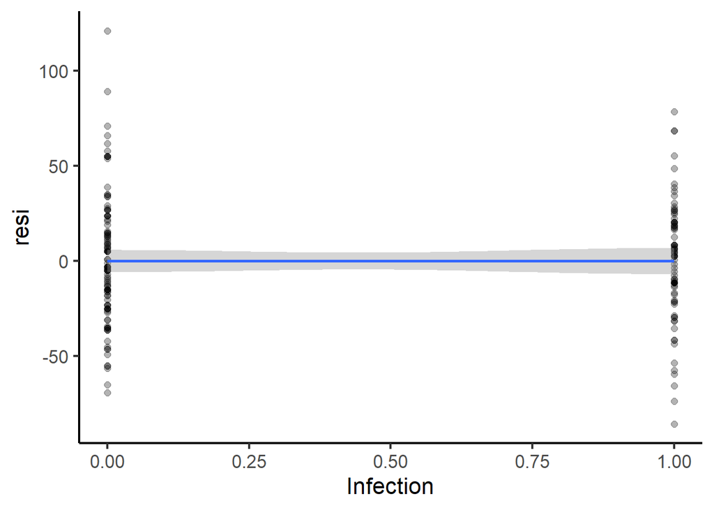

```r
ggplot(data = ICU,
       aes(x = Infection, y = resi)) +
  geom_point(alpha = 0.3,
             size = 2) +
  geom_smooth()
```

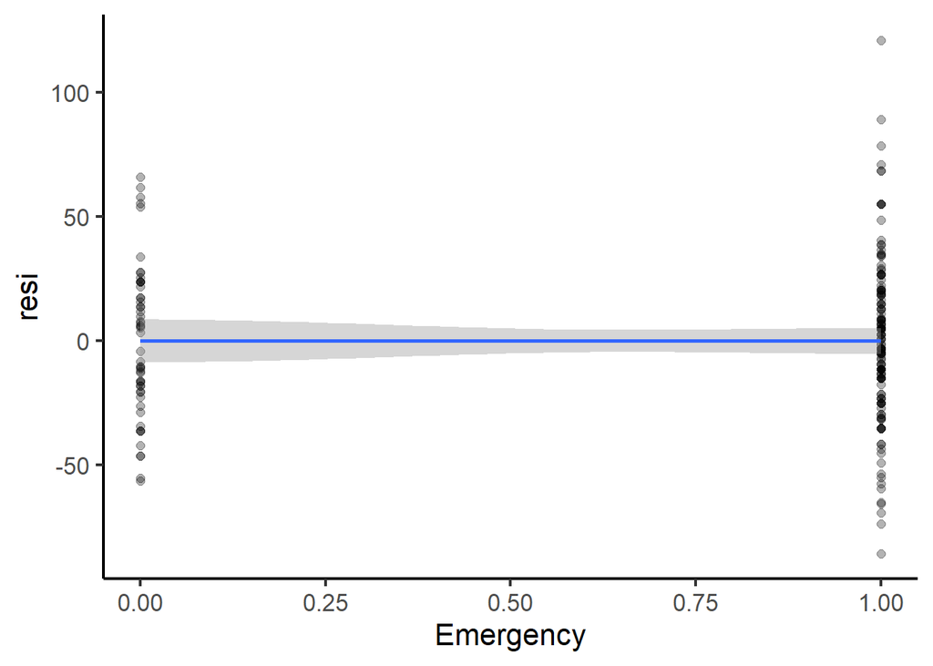

```r
ggplot(data = ICU,
       aes(x = Emergency, y = resi)) +
  geom_point(alpha = 0.3,
             size = 2) +
  geom_smooth()
```

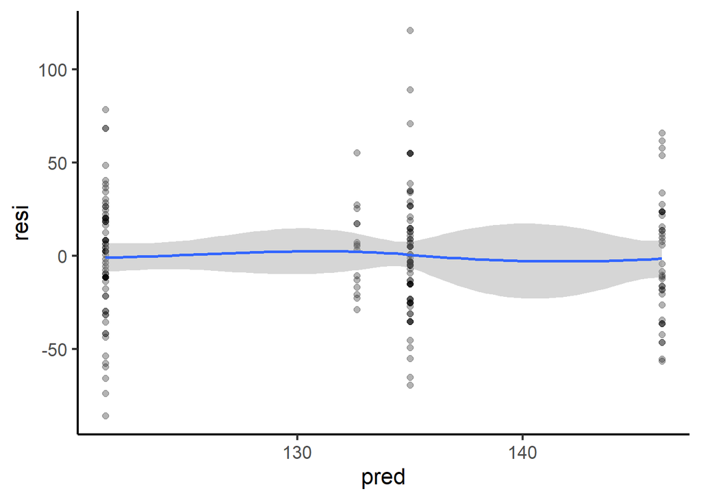

```r
ggplot(data = ICU,
       aes(x = pred, y = resi)) +
  geom_point(alpha = 0.3,
             size = 2) +
  geom_smooth()
```

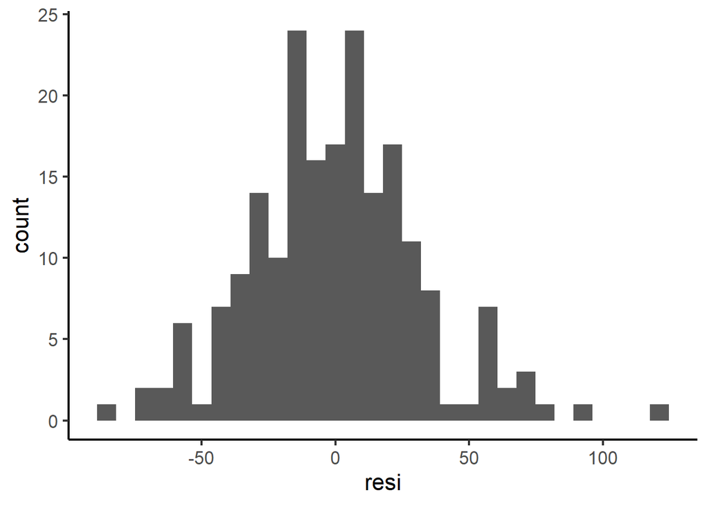

```r
ggplot(data = ICU,
       aes(x = resi)) +
  geom_histogram()
```

6. In plain language, answer the research question: **How do infection status and admission type predict blood pressure?** (This should not be lengthy – just a couple sentences.)